# R-code for reanalysis of the COVID-19 study

This file provides the code of the analysis described in Section 3.5 of Friedrich & Friede (2020). The data set is taken from Gautret et al. (2020), https://doi.org/10.1016/j.ijantimicag.2020.105949, Supplementary Table 1.

## Data preparation

Following Gautret et al. (2020), we imput missing outcomes on Day 6 by a last- observation-carried-forward-approach, i. e. patients with missing PCR are considered positive on Day 6, if they were actually positive the day(s) before.

```r
library(Publish)
```

```r
library(data.table)
library(survival)
library(ggplot2)
library(zoo)
# Data preparation
covid <- readRDS("covid.rds")

# Impute missing outcomes on Day 6
covid[, 8:14] <- t(na.locf(t(covid[, 8:14])))
covid <- as.data.table(covid)
# drop unused variables
covid[, c("D0", "D1", "D2", "D3", "D4", "D5", "azi") := NULL]
## re-label outcome variable
covid[, D6 := ifelse(D6 == "NEG", 1, 0)]
setnames(covid, "D6", "outcome")
covid[, hydro := ifelse(hydro == "no", 0, 1)]
setnames(covid, "hydro", "trt")
```

After setting time since onset of symptoms to zero for asymptomatic patients, two patients with missing time since onset remain. Both patients are classified as URTI and we use the median time since onset (3 days) for URTI-patients to impute these missing values.

```r
# timeonset is zero for asymptomatic patients
covid[clinicalstatus == "Asymptomatic", timeonset := 0]
covid[is.na(timeonset)]
```

```
##    Patient age sex clinicalstatus timeonset trt outcome
## 1:       7  46   M           URTI        NA   0       0
## 2:      13  45   F           URTI        NA   0       0
```

```r
# two missing values remain (both URTI), impute using median in the respective group
replace <- covid[, median(timeonset[clinicalstatus=="URTI"], na.rm =T)]
covid[is.na(timeonset), timeonset := replace]
```

## The PS-model

Our PS-model includes sex, age, clinical status and time since onset of symptoms as explanatory variables.

```r
# propensity score model
propmod <- glm(trt ~ sex + age + clinicalstatus + timeonset,
               family="binomial", data = covid)
# propensity score
covid[, ps := predict(propmod, type = "response")]
```

### Compare propensity score overlap between the two groups

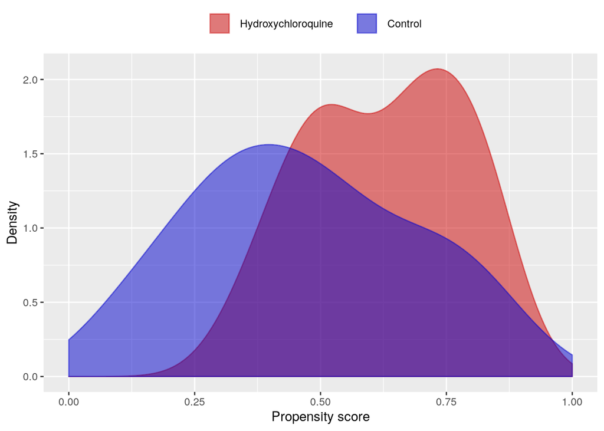

```r
data <- data.frame(treatment = covid$trt, score = covid$ps)

d1 <- density(data$score[data$treatment == 1], from = 0, to = 1, n = 200)
d0 <- density(data$score[data$treatment == 0], from = 0, to = 1, n = 200)
d <- data.frame(x = c(d1$x, d0$x), y = c(d1$y, d0$y), treatment = c(rep("Hydroxychloroquine", length(d1$x)),
                                                                    rep("Control", length(d0$x))))
d$treatment <- factor(d$treatment, levels = c("Hydroxychloroquine", "Control"))
ggplot(d, aes(x = .data$x, y = .data$y)) +
  geom_density(stat = "identity", aes(color = .data$treatment, group = .data$treatment, fill = .data$treatment)) +
  scale_fill_manual(values = c(rgb(0.8, 0, 0, alpha = 0.5),
                                        rgb(0, 0, 0.8, alpha = 0.5))) +
  scale_color_manual(values = c(rgb(0.8, 0, 0, alpha = 0.5),
                                         rgb(0, 0, 0.8, alpha = 0.5))) +
  scale_x_continuous("Propensity score", limits = c(0, 1)) +
  scale_y_continuous("Density", limits = c(0, max(d$y))) +
  theme(legend.title = element_blank(),
                 legend.position = "top",
                 legend.text = element_text(margin = margin(0, 0.5, 0, 0.1, "cm")))
```

### IPTW analysis

```r
# calculate IPTW
covid[trt == 1, w:= 1/ps]
covid[trt == 0, w:= 1/(1-ps)]

# simple model using weighted data with sandwich estimators
fit.iptw <- glm(outcome ~ trt, data = covid, weights = w, family = binomial)
library(sandwich)
library(lmtest)
tt <- coeftest(fit.iptw, vcov = sandwich)
```

### Doubly robust g-computation

The Q-model for the g-computation additionally includes treatment status and the covariate z, which is equal to the IPT weight for the treatment group and equal to the negative IPT weight in the control group.

```r
# simple doubly robust model
covid[trt == 0, z:= -w]
covid[trt == 1, z:= w]

## calculate confidence intervals using bootstrap
###
# function to calculate causal odds ratio including bootstrapped confidence intervals
library(parallel)
bootstrap <- function(data, iter = 10000, seed = 123, ...){

  # function to predict counterfactual outcomes for each hospital using g-formula
  risks <- function(data, ...){
    # fit Q-model for Y~A + L
    fit <- glm(outcome ~  trt + z + sex + age + clinicalstatus + timeonset,
               data, family = binomial)

    predictions <- list()
    pot.outcome <- c(1, 0)
    for(i in 1:2){
      nd <- copy(data)
      nd[, outcome:=NA]
      nd[, trt := pot.outcome[i]]
      predictions[[i]] <- predict(fit, newdata = nd, type = "response")

    }
    names(predictions) <- pot.outcome
    effects <- sapply(FUN = mean, predictions)

    return(effects)
  }

  risks.original <- risks(data)

  # bootstrapping
  boot <- mclapply(X=1:iter, FUN=function(i, ...){
    bindex <- sample(1:NROW(data), size = NROW(data), replace = TRUE)
    bsample <- data[bindex]
    b.risks <- risks(bsample)
    return(b.risks)
  })

 output <- list(risks=risks.original, boot = boot)
  return(output)
}

causal.or <- function(risks, boot,  ...){

  Y_0 <- risks["0"]
  Y_1 <- risks["1"]

  causal.or <- (Y_1/(1-Y_1))/(Y_0/(1-Y_0))

  Y_0_b <- sapply(boot, function(x){x["0"]})
  Y_1_b <- sapply(boot, function(x){x["1"]})

  causal.or.b <- (Y_1_b/(1-Y_1_b))/(Y_0_b/(1-Y_0_b))

  q2.5 <- quantile(causal.or.b, prob = 0.025)
  q97.5 <- quantile(causal.or.b, prob = 0.975)

  COR <- c(q2.5, causal.or, q97.5)
  names(COR) <- c("Lower", "Estimate", "Upper")
  return(COR)
}

boots <- bootstrap(covid)
CIboot <- causal.or(boots$risks, boots$boot)
```

### Matching

The matching procedure results in a data set with 11 controls and 11 treated patients, thus discarding 5 controls and 9 treated patients from the analysis.

```r
## Matching
library(MatchIt)
ps.mod <- matchit(trt ~ sex + age + clinicalstatus + timeonset, data = covid,
                  method = "nearest", replace = FALSE, caliper = 0.2)
m.data <- match.data(ps.mod, distance = "pscore")
```

#### Unconditional analysis

```r
# fit regression model on matched data (unconditional)
fit.match <- glm(outcome ~ trt, data = m.data, family = binomial)
tab <- regressionTable(fit.match)
publish(tab$trt)
```

```
##  Variable Units Missing OddsRatio Lower Upper    Pvalue
##       trt             0 550140527     0   Inf 0.9950476
```

#### Conditional logistic regression

```r
# adjusting for matched pairs
m.data$id <- rownames(m.data)
m.data <- as.data.table(m.data)
rn <- ps.mod$match.matrix[!is.na(ps.mod$match.matrix),]
m.data[id %in% names(rn), matched.id := rn]
m.data[is.na(matched.id), class:= id]
m.data[!is.na(matched.id), class:= matched.id]
# conditional logistic regression
fit.match2 <- clogit(outcome ~ trt + strata(class), data = m.data)
```

#### GEE

```r
# GEE
library(geepack)
# data needs to be ordered
m.data <- m.data[order(class), ]
gee.matched <- geeglm(formula   = outcome ~ trt,
                       family    = binomial(link = "logit"),
                         id        = class,
                         data      = m.data,
                         corstr    = "exchangeable",
                         scale.fix = FALSE)
summary(gee.matched)
```

```
##
## Call:
## geeglm(formula = outcome ~ trt, family = binomial(link = "logit"),
##     data = m.data, id = class, corstr = "exchangeable", scale.fix = FALSE)
##
##  Coefficients:
##               Estimate    Std.err Wald Pr(>|W|)
## (Intercept)     -42.77 6849269.75    0        1
## trt              43.33 6849269.75    0        1
##
## Correlation structure = exchangeable
## Estimated Scale Parameters:
##
##             Estimate Std.err
## (Intercept)      0.5  0.1146
##   Link = identity
##
## Estimated Correlation Parameters:
##         Estimate   Std.err
## alpha -2.647e-23 9.464e-09
## Number of clusters:   11  Maximum cluster size: 2
```

### Fitting the models and putting all results in a table

```r
# crude OR
fit.unadj <- glm(outcome ~ trt, data = covid, family = binomial)
tab.unadj <- regressionTable(fit.unadj)$trt

# PS-covariate adjustment
fit.c <- glm(outcome ~ trt + ps, data = covid, family = binomial)
tab <- regressionTable(fit.c)
tab.c <- tab$trt

# results from the doubly robust g-estimation
tab.g.double <- data.frame(Variable = "trt", Units = "", Missing = "", OddsRatio = CIboot["Estimate"], Lower = CIboot["Lower"], Upper = CIboot["Upper"] , Pvalue = NA)

# results from the IPTW analysis
tab.iptw <- data.frame(Variable = "trt", Units = "", Missing = "", OddsRatio = exp(tt[2, 1]), Lower = exp(confint(tt))[2, 1], Upper = exp(confint(tt))[2, 2] , Pvalue = tt[2, 4])

table <- rbind(tab.unadj, tab.c, tab.iptw, tab.g.double)
table <- table[, c("OddsRatio", "Lower", "Upper")]
table$method <- c("Crude OR", "PS covariate", "IPTW analysis", "Doubly robust g-computation")
knitr::kable(table)
```

|  | OddsRatio | Lower | Upper | method |
| --- | --- | --- | --- | --- |
| 1 | 16.33 | 2.8004 | 95.26 | Crude OR |
| 2 | 16.23 | 2.4004 | 109.77 | PS covariate |
| 3 | 25.94 | 4.2435 | 158.59 | IPTW analysis |
| Estimate | 11.85 | 0.2235 | 280.00 | Doubly robust g-computation |

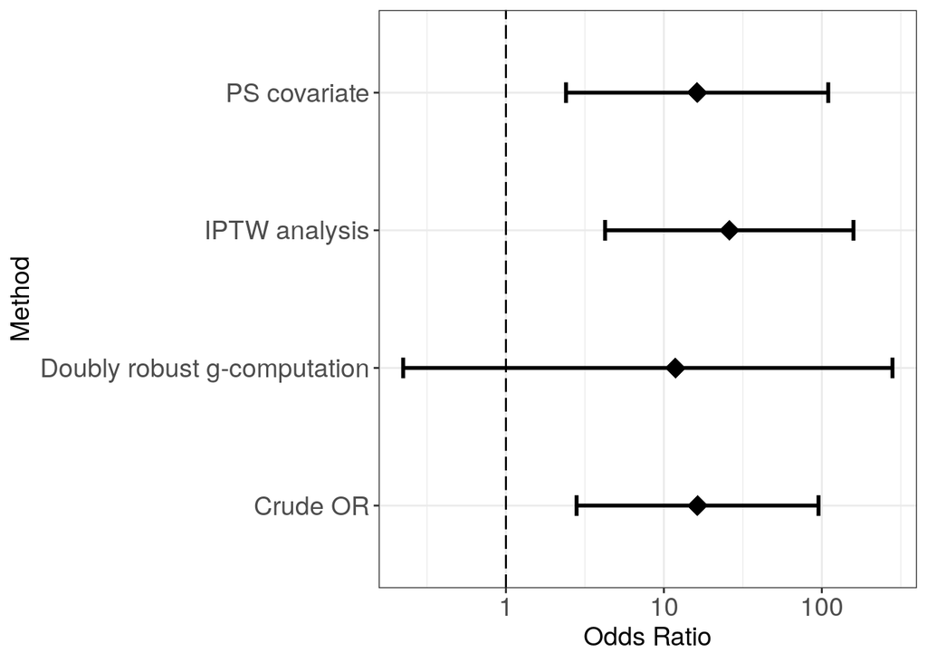

```r
theme_set(theme_bw())
ggplot(table,aes(OddsRatio,method)) +
  geom_point(size=5, shape=18) +
  geom_errorbarh(aes(xmax = Upper, xmin = Lower), height = 0.15, lwd=1) +
  geom_vline(xintercept = 1, linetype = "longdash") +
  scale_x_log10()+
  theme(axis.text = element_text(size=14), axis.title = element_text(size = 14))+
  labs(x="Odds Ratio", y="Method")
```

As we can see in the figure, all four methods (the crude unadjusted as well as the three causal inference methods) yield similar point estimates, which are, however, extremely large. Moreover, the methods differ with respect to statistical significance: The very wide confidence interval obtained by the doubly robust g-computation approach includes 1.

### References

- Friedrich, S and Friede, T (2020). Causal inference methods for small non-randomized studies: Methods and an application in COVID-19.
- Gautret, P., Lagier, J.-C., Parola, P., Meddeb, L., Mailhe, M., Doudier, B., Courjon, J., Giordanengo, V., Vieira, V. E., Dupont, H. T., et al. (2020). Hydroxychloroquine and azithromycin as a treatment of covid-19: results of an open-label non-randomized clinical trial. International journal of antimicrobial agents, page 105949.